# Investigating Frankel and Rose (1996)

# Goals

1. Replicate @frankel1996currency which is a simple probit model but choose probability cutoff to maximise the area under the ROC curve.
2. Show off-the-shelf machine learning on the same dataset: random forest, KNN and SVN

# Summary of findings

1. Probit models often do not need tuning but in the context of imbalanced dataset, we can make a probit model much more sensitive by setting the threshold of classifying a crisis observation low. For instance, as opposed to using a 50% cut-off (i.e. when predicted probability exceeds 0.5, classify the obs as crisis), you can use other cut-off values. Below I used the value to maximise the area under the ROC curve.
2. After making this change, the gap between probit and machine learning algos shrinks although random forest and KNN still do better. Mind you without “tuning” the probit model, its performance is nowhere close to its ML counterparts.

# Note to self

1. The main difficulty of this prediction task comes from the imbalance of classes - we have more non-crisis obs than crisis.
2. Of course one way to do it is to oversample the minority class…which I did in this script, but it just feels unnatural to just generate more data points.
3. In the literature, quite a few papers are horse races of conventional machine learning and almost all manage to show ML algos do better. But of course they are - they are built for predictions.
4. So to stand out, you either come up with a more interpretable model or find a novel way to deal with the class imbalance, or indeed come up with even more advanced models.
5. Intepretability of ML models is big among the ai guys. While the goal here is not casuality but still we will want to know which variable is more important in shaping the forecast. And there are quite a few libraries out there in python that do this: scikit learn plus tons others.
6. When it comes to a novel way to deal with class imbalance, a natural fit (and it so happens it’s one of the models fewer people know of) is an autoeoncoder which can be paired with LSTM and CNN. The idea is simple, just train the model using the non-crisis data, then you will have a good idea of how things play out in no crisis. Then reconstruct the whole dataset using the trained model. Then what you should see is that reconstruction error is low where there is no crsis, and shoots up when there is one. This way you do not have to oversample the dataset to solve the class imbalance.
7. Another additional benefit is that with LSTM you also make use of the time dimension in classification.

# Replicate @frankel1996currency

## Data

```r
#replicating Frankel and Rose (1996)
frankel_rose_data <- read.dta("./stata/cleanrose12.dta")
```

## Data cleaning

The STATA script that does all these transformations can be found in `stata/rose_dat_cleaning.do`

After the re-alignment, the percentage of crisis observations goes up from 6% to around 11%.

## Replication

```r
# run a simple probit model here
frankel_rose_probit <- glm(event ~ comrat + conrat + varrat + fdistock + shorttot + pubrat +
                             multirat + debty + reservem + cacc + defrat + dlcred + dly +
                             istar + overvaln, family = binomial(link = "probit"),
                data = frankel_rose_data)
```

# Moving into machine learning

## Create a score card

```r
records = matrix(NA, nrow = 4, ncol=2)
colnames(records) <- c("train.error", "test.error")
rownames(records) <- c("Probit", "KNN", "Random Forests", "SVM")
```

## Partition the data

```r
frankel_rose_data_ML <- frankel_rose_data_realigned %>%
  mutate(event = ifelse(is.na(event), 0, event),
         event = factor(event, levels = c("0", "1"), labels = c("no", "yes"))) %>%
  # keep a smaller subset, simplify subsequent codes
  select(event, comrat, conrat, varrat,
         fdistock, shorttot, pubrat, multirat, debty,
         reservem, cacc, defrat, dlcred, dly, istar, overvaln)

#frankel_rose_data_ML_cleaned <- frankel_rose_data_ML[complete.cases(frankel_rose_data_ML), ]

# generate row indices for training data
set.seed(2019)
in_train <- createDataPartition(frankel_rose_data_ML$event,
                                p = 0.8, list=FALSE)

training <- frankel_rose_data_ML[in_train, ]
test <- frankel_rose_data_ML[-in_train, ]

# imputing missing variables using bagged trees
# an easy tutorial can be found here:
# http://rismyhammer.com/ml/Pre-Processing.html

# covariates live in columns 2-16
preProc <- preProcess(method = "bagImpute", training[, 2:16])
training[, 2:16] <- predict(preProc, training[, 2:16])
test[, 2:16] <- predict(preProc, test[, 2:16])
```

## Probit

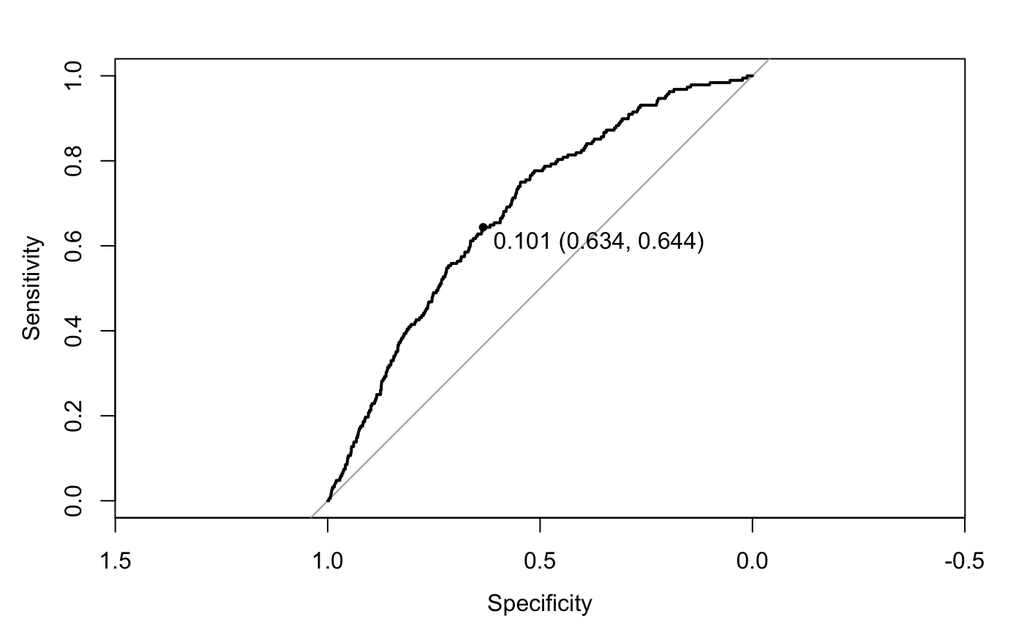

```r
probit_fit <- glm(event ~ ., family = binomial(link = "probit"), data = training)

# Training
prob_train <- predict(probit_fit, type = "response")

# Quick look at the ROC
# Do it by hand for now, can write a function later

prob_train_roc <- roc(training$event, prob_train)

# this shows the roc curve
plot(prob_train_roc, print.thres = "best", print.thres.best.method = "closest.topleft")
```

```r
# look for the best top-left cutoff
prob_train_coords <- coords(prob_train_roc, "best", best.method = "closest.topleft", ret = c("threshold", "accuracy"))

# Choose the best cut-off
prob_train_labels = training %>%
  mutate(predicted.value = factor(ifelse(prob_train <= prob_train_coords$threshold, "no", "yes"), levels = c("no", "yes")))

probit_train_error <- calc_error_rate(predicted.value = prob_train_labels$predicted.value, true.value = training$event)

# Test
prob_test <- predict(probit_fit, newdata = test, type = "response")

prob_test_labels = test %>%
  mutate(predicted.value = factor(ifelse(prob_test <= prob_train_coords$threshold, "no", "yes"), levels = c("no", "yes")))

probit_test_error <- calc_error_rate(predicted.value = prob_test_labels$predicted.value, true.value = test$event)

# write down the training and test errors of the probit model
records[1,] <- c(probit_train_error, probit_test_error)
```

# Entering Machine Learning

## Oversampling technique

Here I show the code that oversamples the minority class (i.e. having a crisis) using the algorithm from @chawla2002smote

Before:

```r
table(training$event)
```

[output not shown]

After oversampling:

```r
set.seed(2019)
smote_train <- SMOTE(event ~ ., data = training)
table(smote_train$event)
```

```
 no yes
752 564
```

Set up train control for all machine learning models

```r
over_sampling <- trainControl(method = "cv",
                              number = 10,
                              verboseIter = F, # don't print iterations
                              sampling = "smote", # over-sampling technique from menardi2014training
                              savePredictions = "final",
                              classProbs=TRUE,
                              summaryFunction = twoClassSummary)
```

## KNN

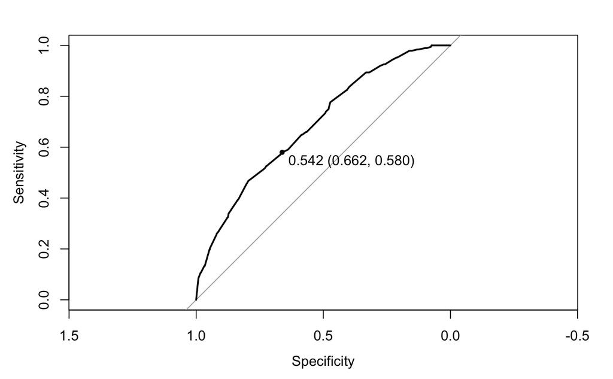

```r
set.seed(2019)

knn_fit <- train(event ~ ., training,
                method = "knn",
                preProcess = c("center","scale"),
                #metric = "ROC",
                tuneLength = 15,
                trControl = over_sampling)

# Training
knn_train <- predict(knn_fit, type = "prob")

# Quick look at the ROC - caret doesn't check probability threshold I think
# Do it by hand for now, can write a function later

knn_train_roc <- roc(training$event, knn_train$yes)

# this shows the roc curve
plot(knn_train_roc, print.thres = "best", print.thres.best.method = "closest.topleft")
```

```r
# look for the best top-left cutoff
knn_train_coords <- coords(knn_train_roc, "best", best.method = "closest.topleft", ret = c("threshold", "accuracy"))

knn_train_labels <- training %>%
  mutate(predicted.value = factor(ifelse(knn_train[,2] <= knn_train_coords$threshold, "no", "yes"), levels = c("no", "yes")))

knn_train_error <- calc_error_rate(predicted.value = knn_train_labels$predicted.value, true.value = training$event)

# Test
knn_test <- predict(knn_fit, newdata = test, type = "prob")

knn_test_labels = test %>%
  mutate(predicted.value = factor(ifelse(knn_test[,2] <= knn_train_coords$threshold, "no", "yes"), levels = c("no", "yes")))

knn_test_error <- calc_error_rate(predicted.value = knn_test_labels$predicted.value, true.value = test$event)

knn_test_roc <- roc(test$event, knn_test$yes)

knn_test_coords <- coords(knn_test_roc, "best", best.method = "closest.topleft", ret = c("threshold", "accuracy"))

# write down the training and test errors of the probit model
records[2,] <- c(knn_train_error, knn_test_error)
```

## Random forest

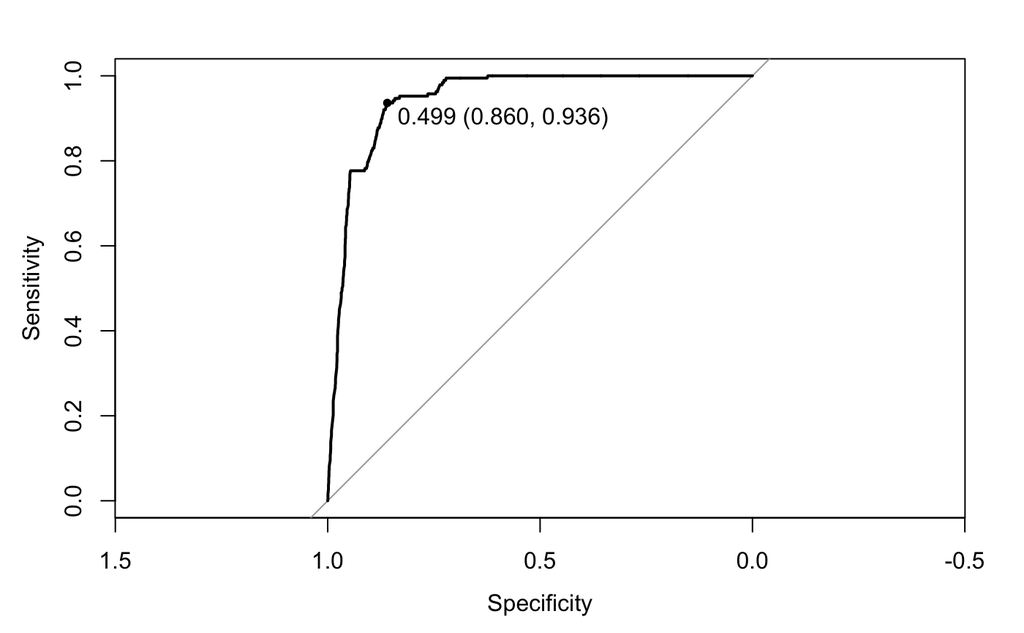

```r
set.seed(2019)

rf_fit <- train(event ~ ., training,
                method = "ranger",
                tuneLength = 15,
                #metric = "ROC",
                trControl = over_sampling)
# Training
rf_train <- predict(rf_fit, training, type = "prob")

# Quick look at the ROC - caret doesn't check probability threshold I think
# Do it by hand for now, can write a function later

rf_train_roc <- roc(training$event, rf_train$yes)

# this shows the roc curve
plot(rf_train_roc, print.thres = "best", print.thres.best.method = "closest.topleft")
```

```r
# look for the best top-left cutoff
rf_train_coords <- coords(rf_train_roc, "best", best.method = "closest.topleft", ret = c("threshold", "accuracy"))

rf_train_labels <- training %>%
  mutate(predicted.value = factor(ifelse(rf_train[,2] <= rf_train_coords$threshold, "no", "yes"), levels = c("no", "yes")))

rf_train_error <- calc_error_rate(predicted.value = rf_train_labels$predicted.value, true.value = training$event)

# Test
rf_test <- predict(rf_fit, newdata = test, type = "prob")

rf_test_labels = test %>%
  mutate(predicted.value = factor(ifelse(rf_test[,2] <= rf_train_coords$threshold, "no", "yes"), levels = c("no", "yes")))

rf_test_error <- calc_error_rate(predicted.value = rf_test_labels$predicted.value, true.value = test$event)

rf_test_roc <- roc(test$event, rf_test$yes)

rf_test_coords <- coords(rf_test_roc, "best", best.method = "closest.topleft", ret = c("threshold", "accuracy"))

# write down the training and test errors of the probit model
records[3,] <- c(rf_train_error, rf_test_error)
```

## SVM

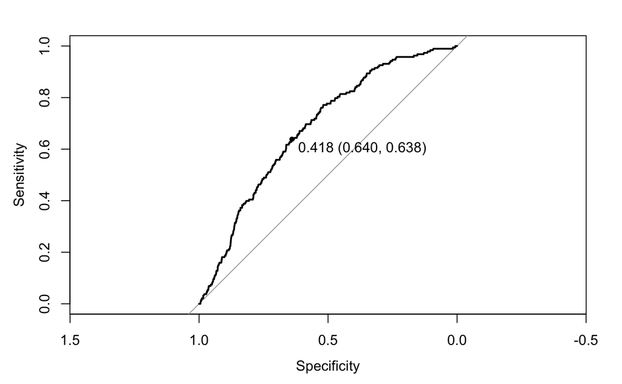

```r
set.seed(2019)

svm_fit <- train(event ~ ., training,
                method = "svmLinear",
                preProcess = c("center","scale"),
                tuneLength = 15,
                #metric = "ROC",
                trControl = over_sampling)

# Training
svm_train <- predict(svm_fit, type = "prob")

# Quick look at the ROC - caret doesn't check probability threshold I think
# Do it by hand for now, can write a function later

svm_train_roc <- roc(training$event, svm_train$yes)

# this shows the roc curve
plot(svm_train_roc, print.thres = "best", print.thres.best.method = "closest.topleft")
```

```r
# look for the best top-left cutoff
svm_train_coords <- coords(svm_train_roc, "best", best.method = "closest.topleft", ret = c("threshold", "accuracy"))

svm_train_labels <- training %>%
  mutate(predicted.value = factor(ifelse(svm_train[,2] <= svm_train_coords$threshold, "no", "yes"), levels = c("no", "yes")))

svm_train_error <- calc_error_rate(predicted.value = svm_train_labels$predicted.value, true.value = training$event)

# Test
svm_test <- predict(svm_fit, newdata = test, type = "prob")

svm_test_labels = test %>%
  mutate(predicted.value = factor(ifelse(svm_test[,2] <= svm_train_coords$threshold, "no", "yes"), levels = c("no", "yes")))

svm_test_error <- calc_error_rate(predicted.value = svm_test_labels$predicted.value, true.value = test$event)

svm_test_roc <- roc(test$event, svm_test$yes)

svm_test_coords <- coords(svm_test_roc, "best", best.method = "closest.topleft", ret = c("threshold", "accuracy"))

svm_test_error <- calc_error_rate(predicted.value = svm_test_labels$predicted.value, true.value = test$event)

# write down the training and test errors of the probit model
records[4,] <- c(svm_train_error, svm_test_error)
```

# Model metrics

## Accuracy

I won’t read too much into it as it’s a imbalanced class problem.

```
               train.error test.error
Probit           0.3649441  0.3867521
KNN              0.3462973  0.3589744
Random Forests   0.1326585  0.2393162
SVM              0.3601492  0.3888889
```

## ROC curves

This is more important.

```r
#ROC on test data

# probit
pred_prob <- prediction(prob_test, test$event)
performance_prob <- performance(pred_prob, measure = "tpr", x.measure="fpr")

# knn
pred_knn <- prediction(knn_test[,2], test$event)
performance_knn <- performance(pred_knn, measure = "tpr", x.measure="fpr")

# rf
pred_rf <- prediction(rf_test[,2], test$event)
performance_rf <- performance(pred_rf, measure = "tpr", x.measure="fpr")

# svm
pred_svm <- prediction(svm_test[,2], test$event)
performance_svm <- performance(pred_svm, measure = "tpr", x.measure="fpr")

#plot
plot(performance_prob, col = 2, lwd = 2, main = "ROC Curves for These Two Classification Methods")

legend(0.6, 0.6, c("Probit", "KNN", "Random Forests", "SVM"), 2:5)
```

```r
#others
plot(performance_knn,col=3,lwd=2,add=TRUE)
plot(performance_rf,col=4,lwd=2,add=TRUE)
```

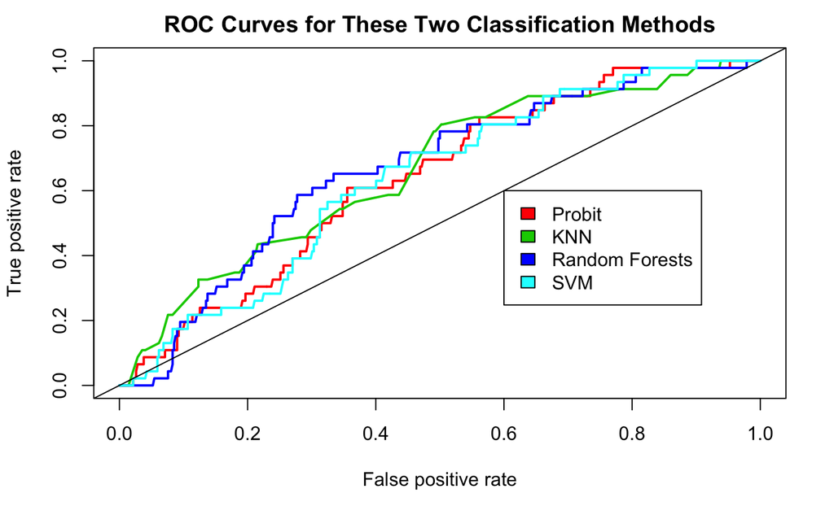

```r
plot(performance_svm,col=5,lwd=2,add=TRUE)

abline(0,1)
```

## AUC

Random forest and KNN stand out but not by much.

```
                     AUC
Probit         0.6380332
KNN            0.6628632
Random Forests 0.6661859
SVM            0.6364362
```

## Trade offs between sensitivity and specificity

Looks like SVM doesn’t bring much to the table…

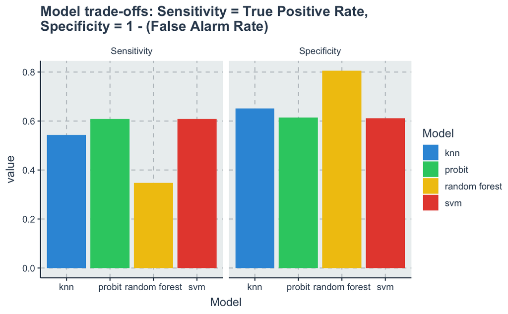

```r
# switching it because the way our table is made
sensitivity <- lapply(confusion, function(x) {data.frame("Sensitivity" = as.numeric(x$byClass[2]))}) %>% bind_rows()
specificity <- lapply(confusion, function(x) {data.frame("Specificity" = as.numeric(x$byClass[1]))}) %>% bind_rows()

main_metrics <- data.frame("Model" = c("probit", "knn", "random forest", "svm"),
                           sensitivity, specificity)

main_metrics_plot <- main_metrics %>% melt(id.var = "Model") %>%
  ggplot(aes(x = Model, y = value)) +
  geom_col(aes(fill = Model)) +
  facet_wrap(~variable) +
  labs(title = "Model trade-offs: Sensitivity = True Positive Rate,\nSpecificity = 1 - (False Alarm Rate)")

main_metrics_plot
```

Probit

```
                  Reference
Prediction         Actual = no Actual = yes
  Prediction = no          259           18
  Prediction = yes         163           28
```

KNN

```
                  Reference
Prediction         Actual = no Actual = yes
  Prediction = no          275           21
  Prediction = yes         147           25
```

Random Forest

```
                  Reference
Prediction         Actual = no Actual = yes
  Prediction = no          340           30
  Prediction = yes          82           16
```

SVM

```
                  Reference
Prediction         Actual = no Actual = yes
  Prediction = no          258           18
  Prediction = yes         164           28
```